# CibNav : construction d’un modèle transparent

Authors

Quentin Loridant

Pierre Camilleri

Published

April 20, 2023

## Préparation des données

```r
df <- tbl(con, "dataset_train") %>%
  collect()
```

```r
df$cible <- as.logical(df$cible)
df$annee_visite <- as.integer(df$annee_visite)
df$id_gin_visite <- as.integer(df$id_gin_visite)
df$sitrep_history <- as.integer(df$sitrep_history)
df$idc_gin_categ_navigation <- fct_recode(
  as.factor(df$idc_gin_categ_navigation),
  "5ème (eaux abritées)"="1",
  "4ème (5 milles des eaux abritées)"="2",
  "4ème (5 milles des eaux abritées)"="3",
  "4ème (5 milles des eaux abritées)"="4",
  "3ème (20 milles de la terre)"="5",
  "3ème (20 milles de la terre)"="7",
  "2ème (200 milles d'un port)"="8",
  "2ème (200 milles d'un port)"="9",
  "1ère"="10",
  "6ème plaisance (2 milles d'un abri)"="11",
  "5ème plaisance (5 milles d'un abri)"="12",
  "4ème plaisance (20 milles d'un abri)"="13",
  "3ème plaisance (60 milles d'un abri)"="14",
)
df <- df %>%
  mutate(
    genre_navigation = fct_lump_min(
      genre_navigation,
      min = 500,
      other_level = "Autre"
    ),
    materiau_coque = fct_recode(
      materiau_coque,
      METAL = "AG/4 - ALU",
      METAL = "ACIER",
      METAL = "ACIER / INOX",
      METAL = "ALLIAGE LEGER",
      BOIS = "BOIS MASSIF",
      BOIS = "BOIS MOULE",
      BOIS = "CONTREPLAQUE",
      PLASTIQUE = "POLYESTER EPOXY",
      PLASTIQUE = "POLYETHYLENE",
      PLASTIQUE = "PLASTIQUE SANDWICH",
      NULL = "INCONNU"
    ),
    type_carburant = fct_lump_min(
      type_carburant,
      min = 500,
      other_level = "Autre"
    ),
    type_moteur = fct_lump_min(
      type_moteur,
      min = 500,
      other_level = "Autre"
      ),
  )

df <- df %>%
  mutate(
   jauge_oslo = ifelse(jauge_oslo == 0, 1, jauge_oslo),
   puissance_administrative = ifelse(puissance_administrative == 0, 1,
                                     puissance_administrative)
   )
df$log_jauge_oslo <- log10(df$jauge_oslo)
df$log_puissance_administrative <- log10(df$puissance_administrative)
df$log_longueur_hors_tout <- log10(df$longueur_hors_tout)
df$longueur_lte12 <- (df$longueur_hors_tout <= 12)
df$longueur_e12 <- (df$longueur_hors_tout > 11.99 & df$longueur_hors_tout < 12.01)
df$longueur_mt12 <- (df$longueur_hors_tout > 12)

# fonction qui permet de ne garder qu'une observation par navire
# to_nav <- function(df) {
#   donnees_navire <- c(
#     "id_nav_flotteur",
#     "num_version",
#     "genre_navigation",
#     "materiau_coque",
#     "situation_flotteur",
#     "type_carburant",
#     "type_moteur",
#     "longueur_hors_tout",
#     "log_longueur_hors_tout",
#     "jauge_oslo",
#     "log_jauge_oslo",
#     "puissance_administrative",
#     "log_puissance_administrative",
#     "age",
#     "longueur_lte12",
#     "longueur_e12",
#     "longueur_mt12",
#     "idc_gin_categ_navigation"
#   )
#   df_nav <- df %>%
#     group_by(id_nav_flotteur) %>%
#     filter(date_visite == max(date_visite)) %>%
#     ungroup() %>%
#     select(any_of(donnees_navire))
#   return(df_nav)
# }
```

# Expérimentation d’une régression poisson simple

```r
mod_pois <- stan_glm(
  nombre_prescriptions_majeurs ~ situation_flotteur,
  data = df %>%
    sample_n(1000),
  family = poisson(link = log)
)
```

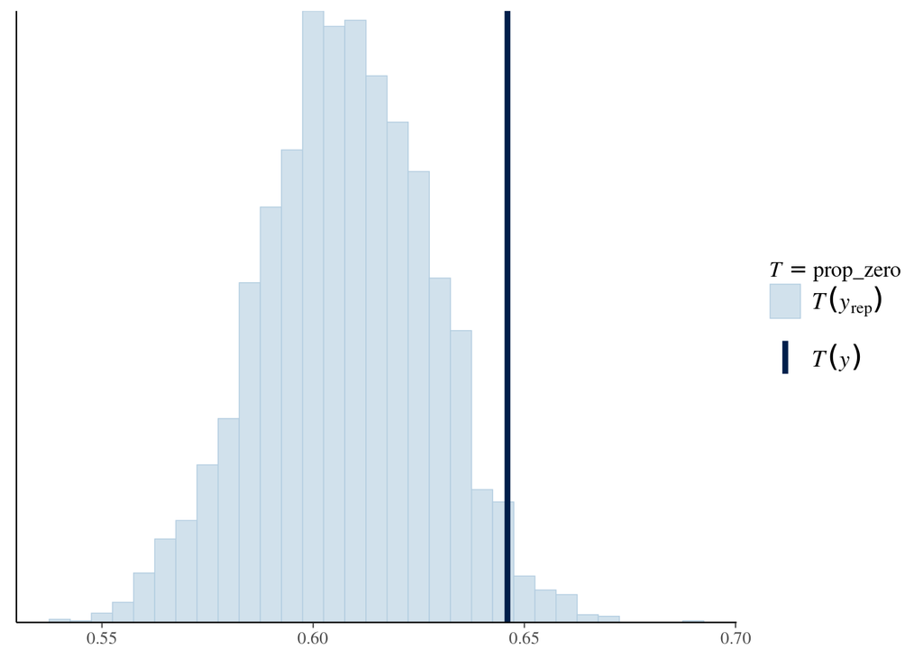

Nombre de visites avec 0 prescriptions majeures, observé et simulé

```r
yrep <- posterior_predict(mod_pois)

prop_zero <- function(y) mean(y == 0)
pp_check(mod_pois, plotfun = "stat", stat = "prop_zero", binwidth = .005)
```

La proportion de “nombre_prescriptions == 0” n’est pas bien capturée par une régression de poisson (surdispersion). Nous essayons donc une distribution plus permissive.

# Expérimentation d’une régression négative binomiale

## Entraînement du modèle

```r
df_mod <- df %>%
  mutate(
         nombre_prescriptions_majeurs_hist =
           scale(nombre_prescriptions_majeurs_hist, center = FALSE),
         nombre_prescriptions_hist =
           scale(nombre_prescriptions_hist, center = FALSE),
         age = scale(age, center = FALSE),
         log_longueur_hors_tout = scale(log_longueur_hors_tout),
         log_puissance_administrative = scale(log_puissance_administrative)
         )
```

Les variables suivant approx une loi normal ont été centrées-réduites, les variables positives suivant une distribution de probabilité décroissante ont seulement été réduites.

```r
mod_nb <- stan_glm(
  nombre_prescriptions_majeurs ~
    # Prescriptions passées
    nombre_prescriptions_majeurs_hist +
    nombre_prescriptions_hist +
    # Caractéristiques du navire
    age +
    log_longueur_hors_tout +
    longueur_e12 +
    longueur_mt12 +
    log_puissance_administrative +
    type_moteur +
    # Usage du navire
    situation_flotteur +
    genre_navigation +
    idc_gin_categ_navigation,
  data = df_mod,
  family = neg_binomial_2
)
```

```r
library(knitr)
knitr::load_cache(
  label = "model_nb_prescriptions_2",
  path = "./3_exploration_glm_cache/html/",
  dir = ".",
  envir = globalenv()
)
```

## Analyse des coefficients du modèle

```r
coefficients(mod_nb)
```

```
                                              (Intercept)
                                              -0.79090266
                        nombre_prescriptions_majeurs_hist
                                               0.12320387
                                nombre_prescriptions_hist
                                               0.02283360
                                                      age
                                              -0.08926545
                                   log_longueur_hors_tout
                                               0.13500815
                                         longueur_e12TRUE
                                               0.34054792
                                        longueur_mt12TRUE
                                               0.06172657
                             log_puissance_administrative
                                              -0.07220603
                                     type_moteurExplosion
                                              -0.41169670
                                         type_moteurAutre
                                              -0.13500147
                         situation_flotteurFrançais pêche
                                               0.32485056
                       genre_navigationNavigation côtière
                                              -0.13092530
                            genre_navigationPêche côtière
                                              -0.10926343
                             genre_navigationPetite pêche
                                              -0.16615134
                             genre_navigationPlaisance NC
                                              -0.65354467
                                    genre_navigationAutre
                                              -0.30120133
idc_gin_categ_navigation4ème (5 milles des eaux abritées)
                                               0.11874070
     idc_gin_categ_navigation3ème (20 milles de la terre)
                                               0.29865057
      idc_gin_categ_navigation2ème (200 milles d'un port)
                                               0.38040284
                             idc_gin_categ_navigation1ère
                                              -0.03306127
                               idc_gin_categ_navigation17
                                               0.19818995
```

### Prescriptions passées

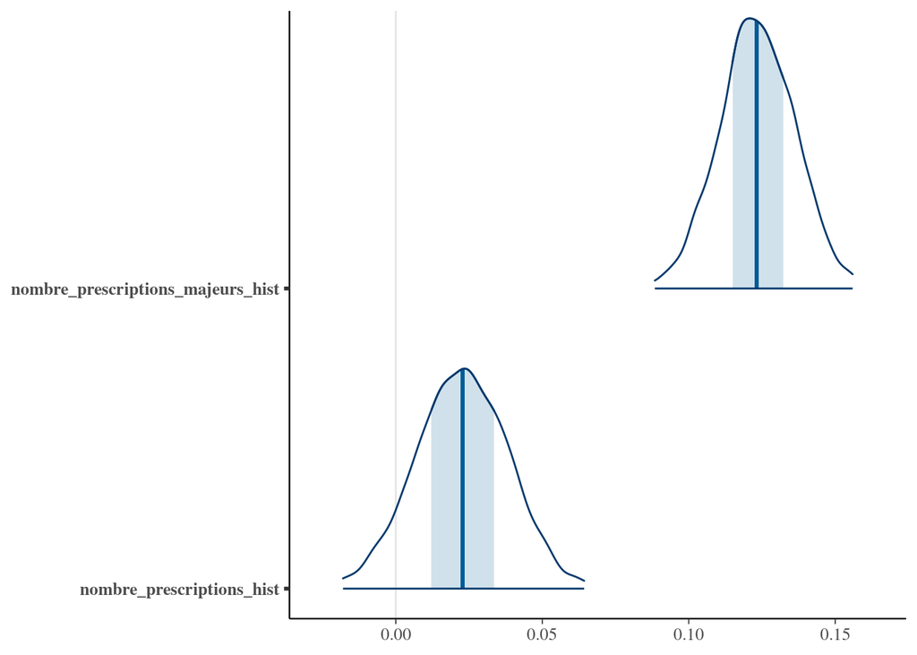

```r
mcmc_areas(
  mod_nb,
  pars = c(
    "nombre_prescriptions_majeurs_hist",
    "nombre_prescriptions_hist"
  ),
  prob_outer = 0.99
)
```

**Exemple d’interprétation** :

- un navire avec 2 prescriptions majeures historiques (pondérées) a en moyenne +13% prescription majeure au contrôle suivant.
- un navire avec 52 prescriptions historiques (pondérées) a en moyenne +2% prescriptions majeures